### Exercise 2: Hydro power generated over time

Task: Plot a column chart hydroelectric power generated over time.

Hint: There are two types of hydroelectric sources in the data: `large_hydro` and `small_hydro`.

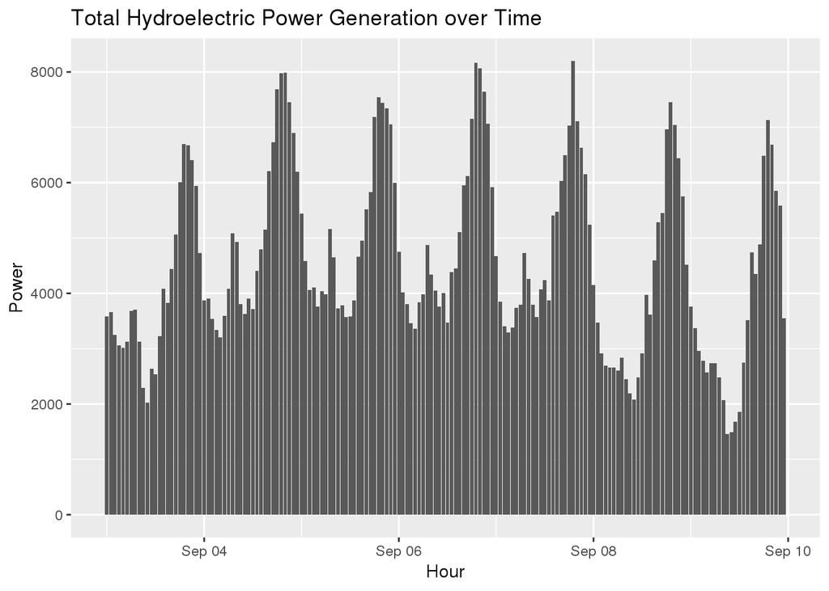

```r
mutate(generation, total_hydro = large_hydro + small_hydro) %>%
  select(datetime, total_hydro) %>%
  ggplot() +
  geom_col(aes(x = datetime, y = total_hydro)) +
  labs(title = "Total Hydroelectric Power Generation over Time", x = "Hour", y= "Power")
```

[figure not shown]

```r
imports %>%
  ggplot() +
  geom_line(aes(x=datetime, y = imports), size = 1.2, col = "red") +
  labs(title = "energy imports over time", x = "date", y="power")
```

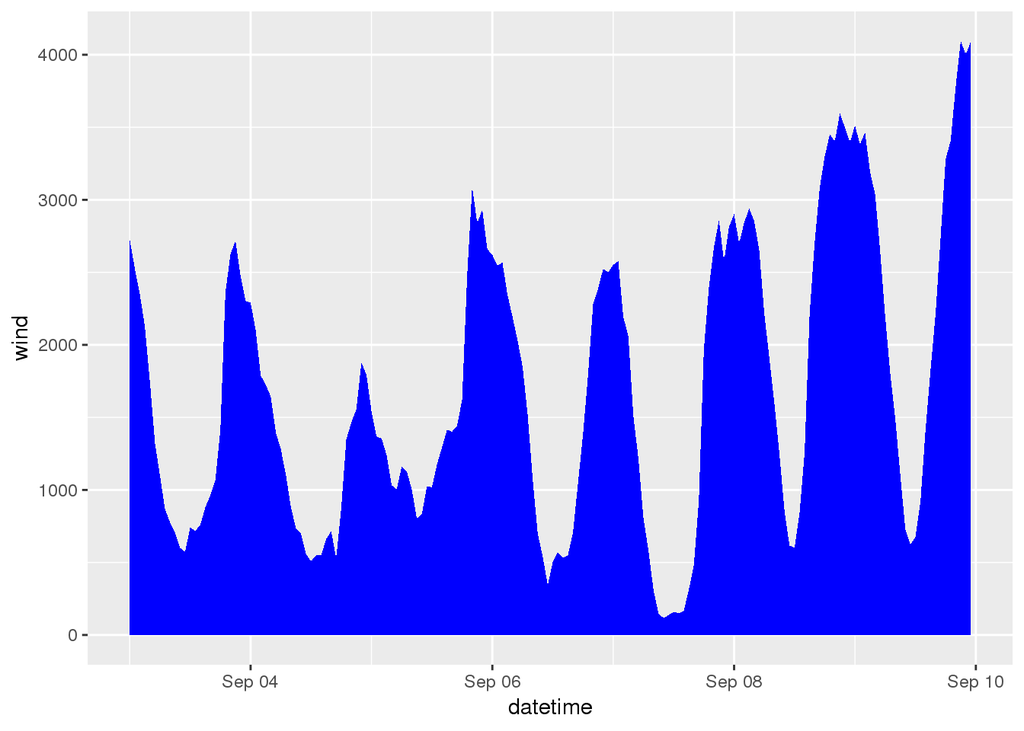

```r
generation %>%
  ggplot() +
  geom_area(aes(x = datetime, y = wind), fill = "blue")
```

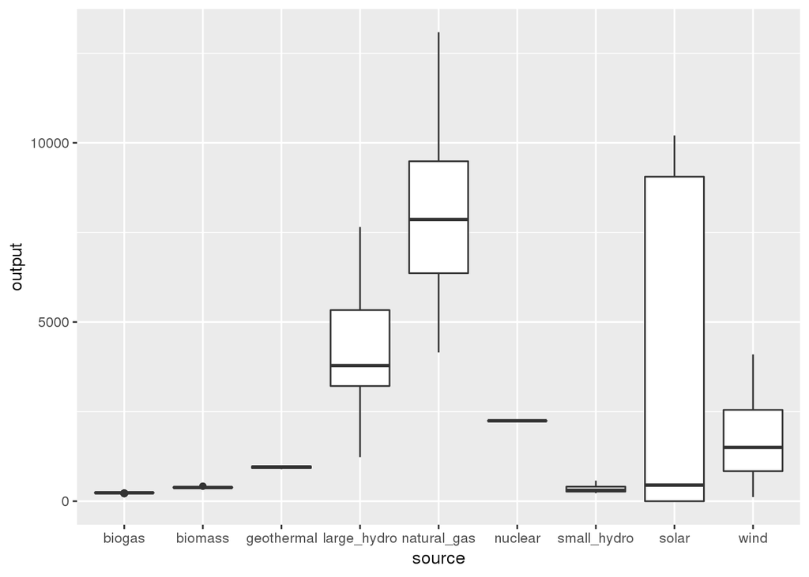

```r
long_gen %>%
  ggplot() +
  geom_boxplot(aes(x=source, y = output))
```

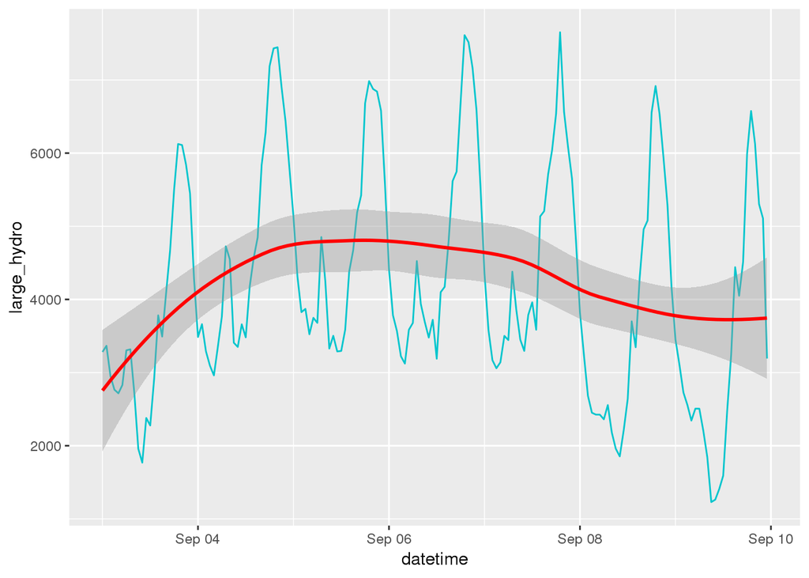

```r
generation %>%
  ggplot() +
  geom_line(aes(x=datetime, y=large_hydro), col="turquoise3") +
            geom_smooth(aes(x=datetime, y=large_hydro), col = "red")
```

### Exercise 3: Total output per source

Task: Create a column chart that shows the total output per source.

- Change the color of the columns to `"darkred"`.
- Add a horizontal line indicating the mean output across all sources. Use the cheatsheet to identify the `geom` function that you need.
- Add a meaningful title and axis labels using `labs()`.

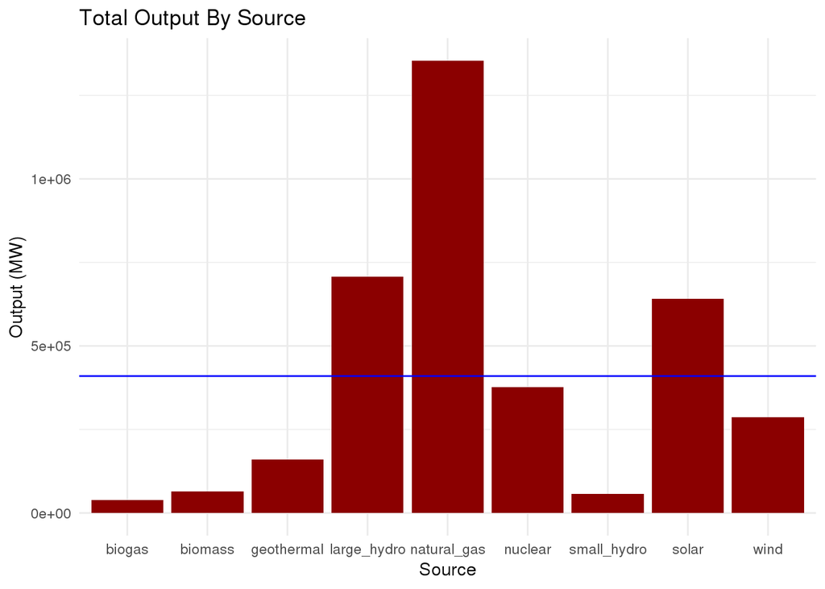

```r
group_by(long_gen, source) %>%
  summarise(total_output = sum(output)) %>%
  ggplot() +
  geom_col(aes(x=source, y=total_output), fill="darkred") +
  geom_hline(aes(yintercept = mean(total_output)), col="blue") +
  labs(title="Total Output By Source", x="Source", y="Output (MW)") +
  theme_minimal()
```

### Exercise 4: Colors and fill

Task: Create a line plot that compares generation of wind, solar, and geothermal energy over time.

Bonus: Set the line size to 1.5.

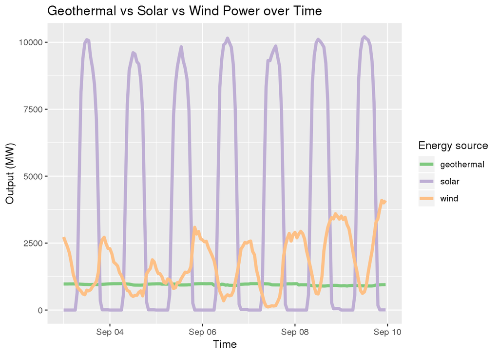

```r
filter(long_merged_energy, (source == "wind") | (source == "solar") | (source == "geothermal")) %>%
  ggplot() +
  geom_line(aes(x = datetime, y = output ,group = source, col=source), size = 1.5) +
  scale_color_brewer(palette="Accent", name="Energy source") +
  labs(title = "Geothermal vs Solar vs Wind Power over Time", x="Time", y="Output (MW)")
```

### Exercise 5: Average hourly output by source

Task: Visualize the average output for each hour of the day, grouped by source.

Hint: You need to identify the output per source per hour (e.g. 01:00, 02:00, etc) averaged over all days.

- You will need to prepare your data using both `dplyr` and `lubridate` functions.
- You can choose which `geom`(s) to use, and how to demarcate groups.
- Bonus: use a scale layer to set a color palette (try `"Set3"`) and change the legend name.
- Remember to add `labs()`!

```r
library(lubridate)
```

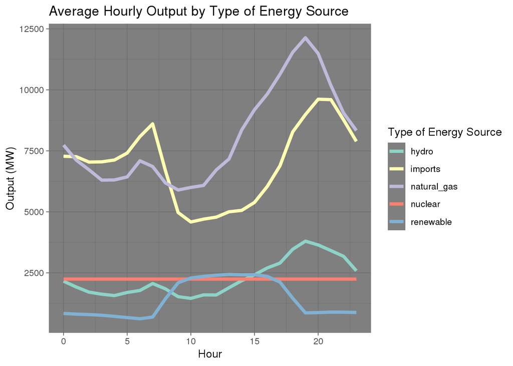

```r
long_merged_energy %>%
  merge(regroup, by.x = "source", by.y="type") %>%
  mutate(hr = hour(datetime)) %>%
  group_by(group,hr)%>%
  summarize(average_output = mean(output)) %>%
  ggplot() +
    geom_line(aes(x=hr,y=average_output, group=group, col=group), size = 1.5)+
    scale_color_brewer(palette="Set3",name="Type of Energy Source")+
    theme_dark()+
    labs(title = "Average Hourly Output by Type of Energy Source", x="Hour", y="Output (MW)")
```

### Exercise 6: Facets

Task: Compare generation patterns for each source in facets. Color the lines using the “group” variable in `regroup`.

Remember: - You will need to prepare your data. Think about the variables that you need: source/type, output, and group. - When you pipe modified data into ggplot, remember that you are grouping in two ways: source/type through facets, and group through color.

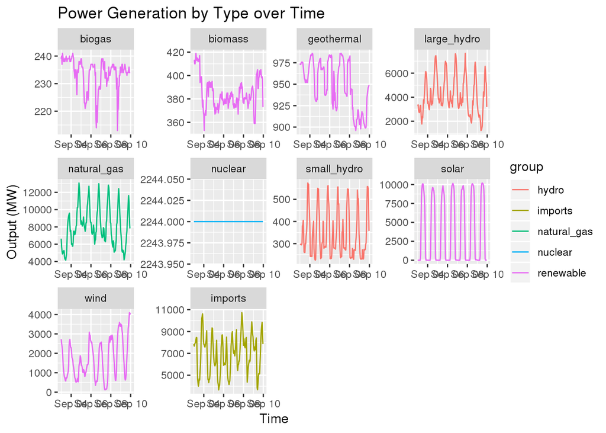

```r
long_merged_energy %>%
  merge(regroup, by.x = "source", by.y = "type") %>%
  ggplot()+
    geom_line(aes(x=datetime, y=output, group = source, col=group)) +
    facet_wrap(~source, scales = "free") +
    labs(title = "Power Generation by Type over Time", x = "Time", y="Output (MW)")
```